# Ventisqueros soil C results

Jessica G. Murray

10/10/2023

### Each dataframe was created with separate scripts:

#### tomst: * TOMST file loop.R & ventisqueros tomst analysis.R * I did the soil moisture curve calculations here. These may need to be revisited because our field values reach the curve's asymptote and it makes the data weird. * More in-depth analyses of soil T and moisture by treatment in the tomst analysis script

#### CO2:

- ventisqueros co2 loop. R & ventisqueros CO2 analysis.R

#### MBC:

- ventisqueros mbc and toc analysis.R (includes the loop for bringing in files as well)

#### CN:

- vent_CN_inorgN_proc_analysis.R (this includes both inorg N and CN data processing)

```r
tomst <- read.csv("TOMST_master_oct20_june22.csv")
CO2 <- read.csv("CO2_master_oct2023.csv")
MBC <- read.csv("MBC.csv")
CN <- read.csv("CN_inorgNmaster.csv")
```

Need to get the dates formatted correctly for merging, add some useful columns, and shave off unneeded ones.

### How does microclimate differ by treatment?

```r
airTmod<-lmer(airT~Treatment*timeofday + (1|Collar), data=tomst)
summary(airTmod)
```

```
## Linear mixed model fit by REML. t-tests use Satterthwaite's method [
## lmerModLmerTest]
## Formula: airT ~ Treatment * timeofday + (1 | Collar)
##    Data: tomst
##
## REML criterion at convergence: 2261573
##
## Scaled residuals:
##     Min      1Q  Median      3Q     Max
## -3.2375 -0.6294  0.0029  0.4217  4.9576
##
## Random effects:
##  Groups   Name        Variance Std.Dev.
##  Collar   (Intercept)  0.07008 0.2647
##  Residual             25.56914 5.0566
## Number of obs: 371995, groups:  Collar, 29
##
## Fixed effects:
##                                   Estimate Std. Error         df t value
## (Intercept)                      1.043e+01  7.003e-02  2.803e+01  148.88
## Treatmentwarming                 2.358e+00  1.008e-01  2.802e+01   23.39
## timeofdaynight                  -6.840e+00  2.341e-02  3.720e+05 -292.20
## Treatmentwarming:timeofdaynight -2.456e+00  3.365e-02  3.720e+05  -72.99
##                                 Pr(>|t|)
## (Intercept)                       <2e-16 ***
## Treatmentwarming                  <2e-16 ***
## timeofdaynight                    <2e-16 ***
## Treatmentwarming:timeofdaynight   <2e-16 ***
## ---
## Signif. codes:  0 '***' 0.001 '**' 0.01 '*' 0.05 '.' 0.1 ' ' 1
##
## Correlation of Fixed Effects:
##             (Intr) Trtmnt tmfdyn
## Trtmntwrmng -0.695
## timefdynght -0.139  0.097
## Trtmntwrmn:  0.097 -0.139 -0.696
```

```r
surfaceTmod<-lmer(surfaceT~Treatment*timeofday + (1|Collar), data=tomst)
summary(surfaceTmod)
```

```
## Linear mixed model fit by REML. t-tests use Satterthwaite's method [
## lmerModLmerTest]
## Formula: surfaceT ~ Treatment * timeofday + (1 | Collar)
##    Data: tomst
##
## REML criterion at convergence: 2387302
##
## Scaled residuals:
##     Min      1Q  Median      3Q     Max
## -2.8583 -0.6298 -0.0044  0.3937  4.4188
##
## Random effects:
##  Groups   Name        Variance Std.Dev.
##  Collar   (Intercept)  0.3172  0.5632
##  Residual             35.8481  5.9873
## Number of obs: 371995, groups:  Collar, 29
##
## Fixed effects:
##                                   Estimate Std. Error         df  t value
## (Intercept)                      1.244e+01  1.465e-01  2.733e+01   84.882
## Treatmentwarming                 1.867e+00  2.109e-01  2.732e+01    8.852
## timeofdaynight                  -9.203e+00  2.772e-02  3.720e+05 -332.039
## Treatmentwarming:timeofdaynight -1.638e+00  3.984e-02  3.720e+05  -41.105
##                                 Pr(>|t|)
## (Intercept)                      < 2e-16 ***
## Treatmentwarming                1.64e-09 ***
## timeofdaynight                   < 2e-16 ***
## Treatmentwarming:timeofdaynight  < 2e-16 ***
## ---
## Signif. codes:  0 '***' 0.001 '**' 0.01 '*' 0.05 '.' 0.1 ' ' 1
##
## Correlation of Fixed Effects:
##             (Intr) Trtmnt tmfdyn
## Trtmntwrmng -0.695
## timefdynght -0.079  0.055
## Trtmntwrmn:  0.055 -0.079 -0.696
```

```r
soilTmod<-lmer(subsoilT~Treatment*timeofday + (1|Collar), data=tomst)
summary(soilTmod)
```

```
## Linear mixed model fit by REML. t-tests use Satterthwaite's method [
## lmerModLmerTest]
## Formula: subsoilT ~ Treatment * timeofday + (1 | Collar)
##    Data: tomst
##
## REML criterion at convergence: 1776578
##
## Scaled residuals:
##     Min      1Q  Median      3Q     Max
## -2.9815 -0.6275 -0.0483  0.5702  4.4756
##
## Random effects:
##  Groups   Name        Variance Std.Dev.
##  Collar   (Intercept) 0.4415   0.6645
##  Residual             6.9405   2.6345
## Number of obs: 371995, groups:  Collar, 29
##
## Fixed effects:
##                                   Estimate Std. Error         df  t value
## (Intercept)                      1.184e+01  1.718e-01  2.705e+01   68.922
## Treatmentwarming                 9.624e-01  2.472e-01  2.705e+01    3.893
## timeofdaynight                  -3.762e+00  1.220e-02  3.720e+05 -308.455
## Treatmentwarming:timeofdaynight  4.746e-02  1.753e-02  3.720e+05    2.707
##                                 Pr(>|t|)
## (Intercept)                      < 2e-16 ***
## Treatmentwarming                0.000585 ***
## timeofdaynight                   < 2e-16 ***
## Treatmentwarming:timeofdaynight 0.006787 **
## ---
## Signif. codes:  0 '***' 0.001 '**' 0.01 '*' 0.05 '.' 0.1 ' ' 1
##
## Correlation of Fixed Effects:
##             (Intr) Trtmnt tmfdyn
## Trtmntwrmng -0.695
## timefdynght -0.030  0.021
## Trtmntwrmn:  0.021 -0.030 -0.696
```

```r
#for graphs of microclimate, see ventisqueros tomst analysis script

## averaging microclim data by the hour so it can be merged with CO2.
hourlytomst <- tomst %>%
  group_by(Collar, Day, Hour, Month, Year) %>%
  summarise(soilT = mean(subsoilT, na.rm=TRUE),
            surfaceT = mean(surfaceT, na.rm=TRUE),
            airT = mean(airT, na.rm = TRUE),
            VWC = mean(VWC_cm3cm3, na.rm=TRUE),
            GSM = mean(GSM_gg, na.rm = TRUE))
tomstCO2 <- left_join(cleanCO2, hourlytomst, relationship = "many-to-many")
## create a new column with "timepoint", since some measurements were done of 2-3 days "Day" doesn't really represent "timepoint"
tomstCO2 <- tomstCO2 %>%
  mutate(timepoint = case_when(Day== "2021-10-25" | Day =="2021-10-26" |Day =="2021-10-24" ~ "10/25/21",
                               Day == "2021-11-05" | Day == "2021-11-06"  ~ "11/05/21",
                               Day =="2021-11-16" ~ "11/16/21",
                               Day =="2021-12-01" | Day == "2021-12-03" ~ "12/1/21",
                               Day =="2021-12-17" ~ "12/17/21",
                               Day =="2022-01-04" ~ "1/04/22",
                               Day =="2022-01-21" | Day == "2022-01-23" ~ "1/21/22",
                               Day =="2022-02-02" ~ "2/02/22"))
tomstCO2$timepoint.tidy <- mdy(tomstCO2$timepoint)
```

Patterns in CO2 across time

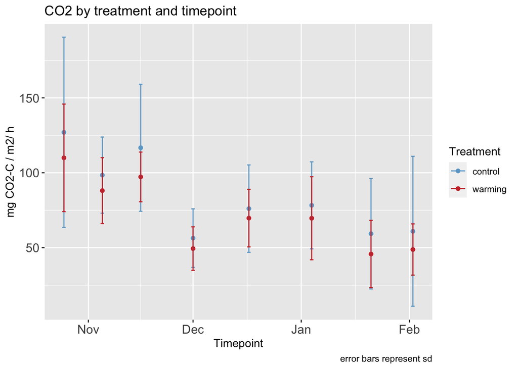

```
## 'Day', 'Month', 'Year'. You can override using the `.groups` argument.
```

```
##    mean_soilT mean_surfaceT     mean_airT      mean_gsm
##      3.455881     30.933201     23.673719      2.180725
```

```
## Linear mixed model fit by REML. t-tests use Satterthwaite's method [
## lmerModLmerTest]
## Formula: mean_CO2_mgCm2h ~ mean_soilT + mean_gsm + Treatment + (1 | Collar)
##    Data: tomstCO2day
##
## REML criterion at convergence: 1428.2
##
## Scaled residuals:
##     Min      1Q  Median      3Q     Max
## -1.7757 -0.5483 -0.1865  0.2968  5.0662
##
## Random effects:
##  Groups   Name        Variance Std.Dev.
##  Collar   (Intercept)  670.5   25.89
##  Residual             1034.4   32.16
## Number of obs: 145, groups:  Collar, 23
##
## Fixed effects:
##                  Estimate Std. Error      df t value Pr(>|t|)
## (Intercept)       -24.162     33.769 140.949  -0.716 0.475472
## mean_soilT          1.354      1.044 136.142   1.297 0.196862
## mean_gsm          186.365     47.411 133.848   3.931 0.000135 ***
## Treatmentwarming   -8.540     12.216  19.364  -0.699 0.492821
## ---
## Signif. codes:  0 '***' 0.001 '**' 0.01 '*' 0.05 '.' 0.1 ' ' 1
##
## Correlation of Fixed Effects:
##             (Intr) mn_slT mn_gsm
## mean_soilT  -0.861
## mean_gsm    -0.924  0.710
## Trtmntwrmng -0.058 -0.146 -0.082
```

### Examining treatment effects on CO2

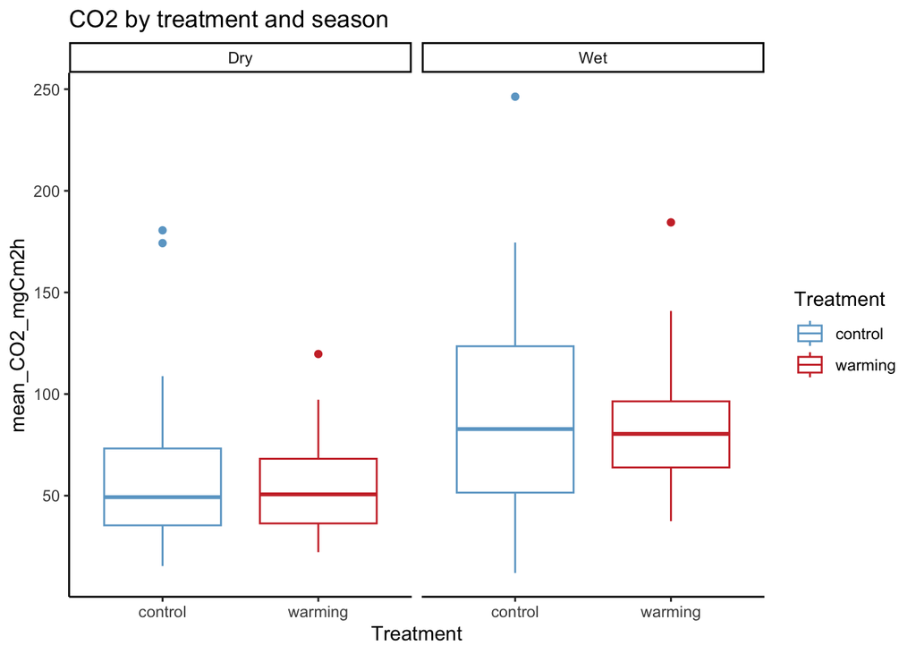

```
## Linear mixed model fit by REML. t-tests use Satterthwaite's method [
## lmerModLmerTest]
## Formula: mean_CO2_mgCm2h ~ Treatment * season * Block + (1 | Collar)
##    Data: tomstCO2day
##
## REML criterion at convergence: 1353.5
##
## Scaled residuals:
##     Min      1Q  Median      3Q     Max
## -1.9103 -0.5303 -0.1265  0.4051  5.2590
##
## Random effects:
##  Groups   Name        Variance Std.Dev.
##  Collar   (Intercept) 386.8    19.67
##  Residual             948.6    30.80
## Number of obs: 150, groups:  Collar, 24
##
## Fixed effects:
##                                   Estimate Std. Error      df t value Pr(>|t|)
## (Intercept)                         27.879     16.942  38.339   1.646   0.1080
## Treatmentwarming                    20.552     23.960  38.339   0.858   0.3964
## seasonWet                           40.011     16.233 117.858   2.465   0.0151
## Block2                             -10.460     27.065  38.774  -0.386   0.7013
## Block3                              62.510     23.514  35.768   2.658   0.0117
## Block4                              44.922     21.695  34.073   2.071   0.0460
## Treatmentwarming:seasonWet          -1.305     22.957 117.858  -0.057   0.9548
## Treatmentwarming:Block2              3.696     37.483  36.388   0.099   0.9220
## Treatmentwarming:Block3            -70.351     32.994  34.779  -2.132   0.0401
## Treatmentwarming:Block4            -18.003     30.553  33.584  -0.589   0.5596
## seasonWet:Block2                     4.308     25.182 120.216   0.171   0.8645
## seasonWet:Block3                   -27.112     21.784 118.324  -1.245   0.2157
## seasonWet:Block4                    -4.706     20.154 118.003  -0.234   0.8158
## Treatmentwarming:seasonWet:Block2    9.555     35.066 119.613   0.272   0.7857
## Treatmentwarming:seasonWet:Block3   13.775     30.607 118.207   0.450   0.6535
## Treatmentwarming:seasonWet:Block4  -20.830     28.440 118.018  -0.732   0.4654
##
## (Intercept)
## Treatmentwarming
## seasonWet                         *
## Block2
## Block3                            *
## Block4                            *
## Treatmentwarming:seasonWet
## Treatmentwarming:Block2
## Treatmentwarming:Block3           *
## Treatmentwarming:Block4
## seasonWet:Block2
## seasonWet:Block3
## seasonWet:Block4
## Treatmentwarming:seasonWet:Block2
## Treatmentwarming:seasonWet:Block3
## Treatmentwarming:seasonWet:Block4
## ---
## Signif. codes:  0 '***' 0.001 '**' 0.01 '*' 0.05 '.' 0.1 ' ' 1
```

```
##
## Correlation matrix not shown by default, as p = 16 > 12.
## Use print(x, correlation=TRUE)  or
##     vcov(x)        if you need it
```

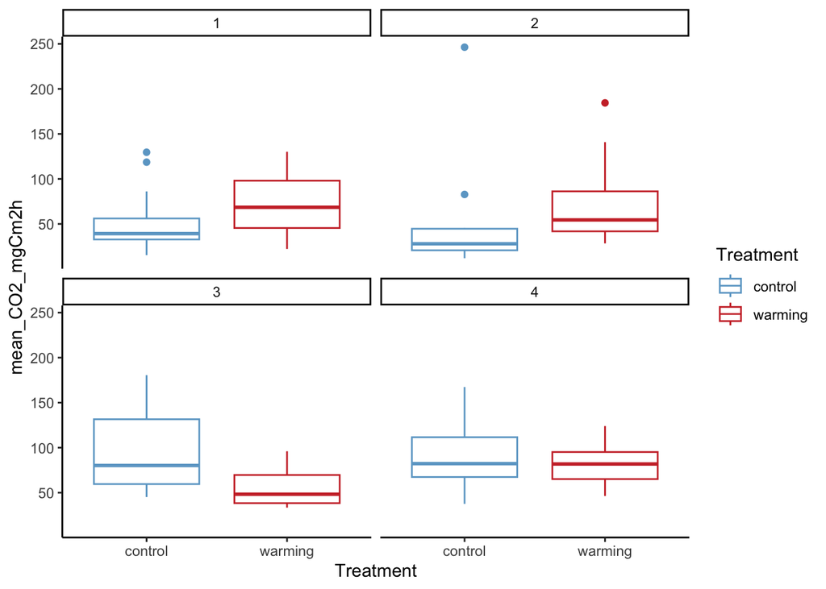

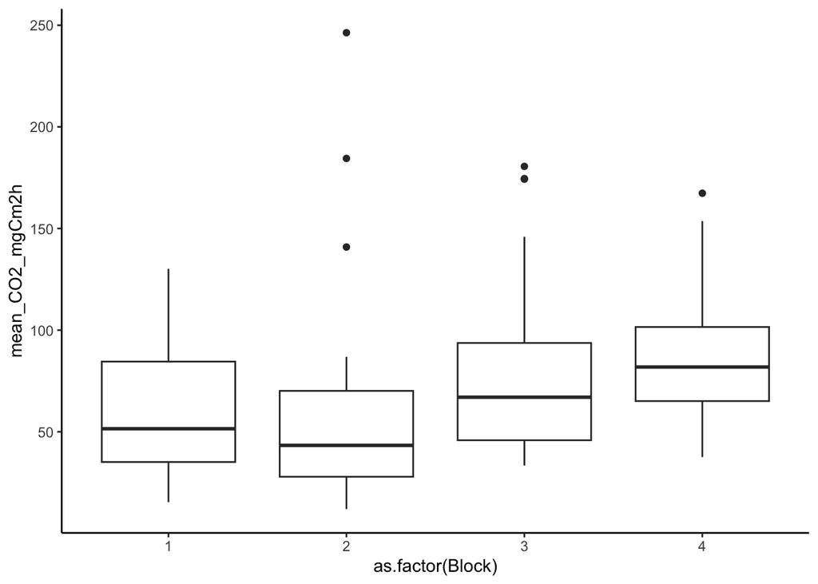

### Season and block are significant main effects but there is no effect of treatment on CO2. Visually though, there looks to be an interaction between block and treatment when you look at overall patterns.

### What can the soil data tell us about the drivers behind this massive variation in response?

### Adding soil data (TOC, CN, Inorg N)

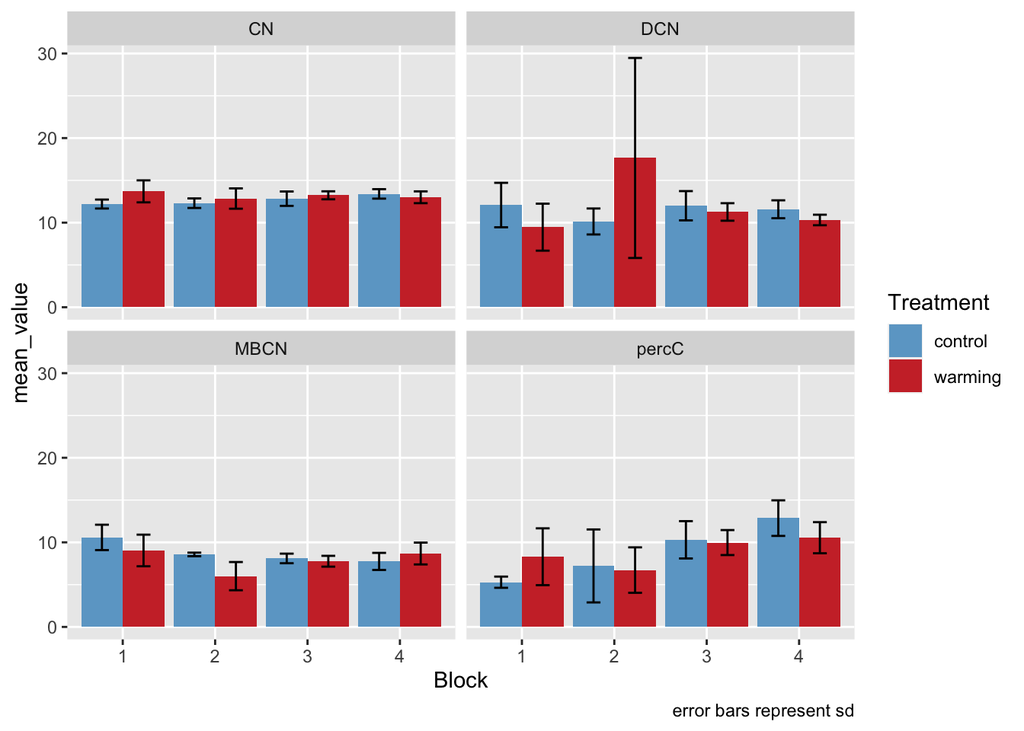

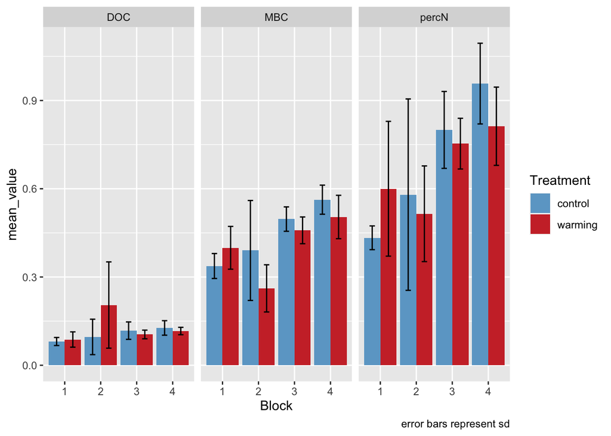

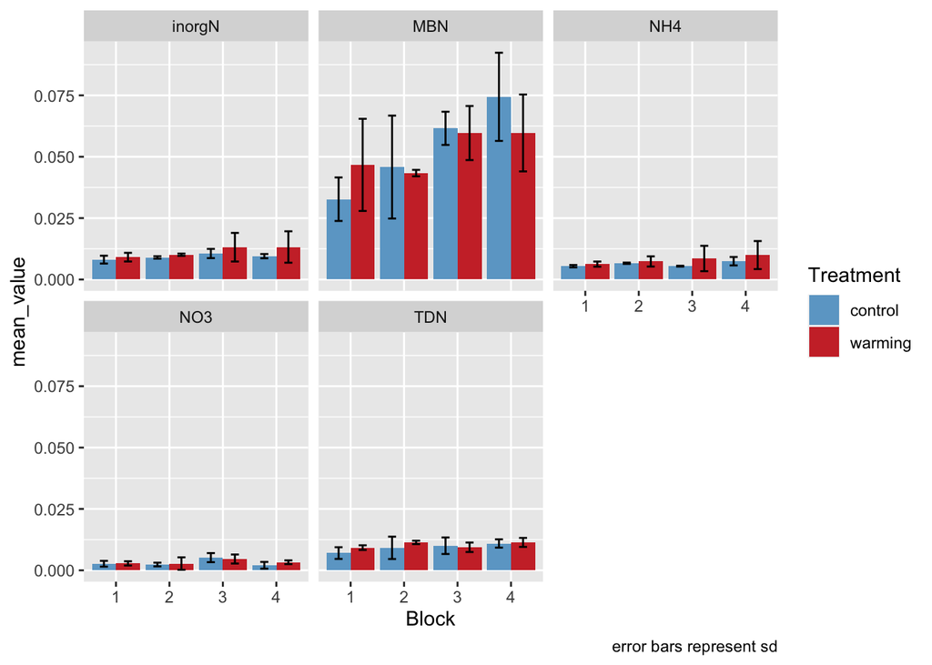

## how do soil variables vary across Blocks and treatments?

```
##
## Call:
## lm(formula = percC ~ Block * Treatment, data = dry_data)
##
## Residuals:
##     Min      1Q  Median      3Q     Max
## -3.3467 -1.6569  0.3371  1.4169  3.3733
##
## Coefficients:
##                         Estimate Std. Error t value Pr(>|t|)
## (Intercept)                5.287      1.345   3.931  0.00119 **
## Block2                     1.923      2.126   0.905  0.37913
## Block3                     5.013      1.902   2.636  0.01797 *
## Block4                     7.576      1.779   4.258  0.00060 ***
## Treatmentwarming           3.010      1.902   1.583  0.13306
## Block2:Treatmentwarming   -3.500      3.007  -1.164  0.26151
## Block3:Treatmentwarming   -3.337      2.690  -1.241  0.23264
## Block4:Treatmentwarming   -5.325      2.516  -2.117  0.05032 .
## ---
## Signif. codes:  0 '***' 0.001 '**' 0.01 '*' 0.05 '.' 0.1 ' ' 1
##
## Residual standard error: 2.329 on 16 degrees of freedom
## Multiple R-squared:  0.6082, Adjusted R-squared:  0.4368
## F-statistic: 3.548 on 7 and 16 DF,  p-value: 0.01703
```

```
## # A tibble: 35 × 9
##    term            group1  group2 null.value estimate conf.low conf.high   p.adj
##  * <chr>           <chr>   <chr>       <dbl>    <dbl>    <dbl>     <dbl>   <dbl>
##  1 Block           1       2               0    0.173   -4.13       4.47 0.999
##  2 Block           1       3               0    3.34    -0.502      7.19 0.1
##  3 Block           1       4               0    4.91     1.31       8.51 0.00621
##  4 Block           2       3               0    3.17    -1.13       7.47 0.192
##  5 Block           2       4               0    4.74     0.659      8.82 0.0202
##  6 Block           3       4               0    1.57    -2.03       5.17 0.608
##  7 Treatment       control warmi…          0   -0.183   -2.20       1.83 0.85
##  8 Block:Treatment 1:cont… 2:con…          0    1.92    -5.44       9.28 0.981
##  9 Block:Treatment 1:cont… 3:con…          0    5.01    -1.57      11.6  0.213
## 10 Block:Treatment 1:cont… 4:con…          0    7.58     1.42      13.7  0.0108
## # ℹ 25 more rows
## # ℹ 1 more variable: p.adj.signif <chr>
```

```
##
## Call:
## lm(formula = percN ~ Block * Treatment, data = dry_data)
##
## Residuals:
##      Min       1Q   Median       3Q      Max
## -0.23000 -0.09875  0.01458  0.08812  0.25000
##
## Coefficients:
##                         Estimate Std. Error t value Pr(>|t|)
## (Intercept)              0.43333    0.09119   4.752 0.000217 ***
## Block2                   0.14667    0.14418   1.017 0.324176
## Block3                   0.36667    0.12896   2.843 0.011743 *
## Block4                   0.52417    0.12063   4.345 0.000501 ***
## Treatmentwarming         0.16667    0.12896   1.292 0.214574
## Block2:Treatmentwarming -0.23167    0.20390  -1.136 0.272621
## Block3:Treatmentwarming -0.21333    0.18238  -1.170 0.259235
## Block4:Treatmentwarming -0.31167    0.17060  -1.827 0.086427 .
## ---
## Signif. codes:  0 '***' 0.001 '**' 0.01 '*' 0.05 '.' 0.1 ' ' 1
##
## Residual standard error: 0.1579 on 16 degrees of freedom
## Multiple R-squared:  0.6345, Adjusted R-squared:  0.4745
## F-statistic: 3.967 on 7 and 16 DF,  p-value: 0.01066
```

```
## # A tibble: 35 × 9
##    term            group1  group2 null.value estimate conf.low conf.high   p.adj
##  * <chr>           <chr>   <chr>       <dbl>    <dbl>    <dbl>     <dbl>   <dbl>
##  1 Block           1       2               0   0.0308 -2.61e-1     0.323 0.99
##  2 Block           1       3               0   0.260  -8.91e-4     0.521 0.0509
##  3 Block           1       4               0   0.368   1.24e-1     0.612 0.00268
##  4 Block           2       3               0   0.229  -6.25e-2     0.521 0.153
##  5 Block           2       4               0   0.337   6.08e-2     0.614 0.0144
##  6 Block           3       4               0   0.108  -1.36e-1     0.352 0.594
##  7 Treatment       control warmi…          0  -0.0292 -1.66e-1     0.108 0.657
##  8 Block:Treatment 1:cont… 2:con…          0   0.147  -3.53e-1     0.646 0.965
##  9 Block:Treatment 1:cont… 3:con…          0   0.367  -7.98e-2     0.813 0.151
## 10 Block:Treatment 1:cont… 4:con…          0   0.524   1.07e-1     0.942 0.00913
## # ℹ 25 more rows
## # ℹ 1 more variable: p.adj.signif <chr>
```

```
##
## Call:
## lm(formula = MBC ~ Block * Treatment, data = dry_data)
##
## Residuals:
##      Min       1Q   Median       3Q      Max
## -0.12013 -0.04291 -0.01403  0.04957  0.12013
##
## Coefficients:
##                         Estimate Std. Error t value Pr(>|t|)
## (Intercept)              0.33740    0.04101   8.228 3.85e-07 ***
## Block2                   0.05279    0.06484   0.814 0.427456
## Block3                   0.15951    0.05799   2.750 0.014220 *
## Block4                   0.22540    0.05425   4.155 0.000745 ***
## Treatmentwarming         0.06185    0.05799   1.066 0.302051
## Block2:Treatmentwarming -0.19069    0.09170  -2.080 0.053997 .
## Block3:Treatmentwarming -0.10014    0.08201  -1.221 0.239760
## Block4:Treatmentwarming -0.12069    0.07672  -1.573 0.135228
## ---
## Signif. codes:  0 '***' 0.001 '**' 0.01 '*' 0.05 '.' 0.1 ' ' 1
##
## Residual standard error: 0.07103 on 16 degrees of freedom
## Multiple R-squared:  0.7045, Adjusted R-squared:  0.5753
## F-statistic:  5.45 on 7 and 16 DF,  p-value: 0.002415
```

```
## # A tibble: 35 × 9
##    term            group1  group2 null.value estimate conf.low conf.high   p.adj
##  * <chr>           <chr>   <chr>       <dbl>    <dbl>    <dbl>     <dbl>   <dbl>
##  1 Block           1       2               0  -0.0426 -0.174      0.0886 0.79
##  2 Block           1       3               0   0.109  -0.00789    0.227  0.0719
##  3 Block           1       4               0   0.165   0.0553     0.275  0.00277
##  4 Block           2       3               0   0.152   0.0208     0.283  0.0205
##  5 Block           2       4               0   0.208   0.0832     0.332  0.00107
##  6 Block           3       4               0   0.0556 -0.0541     0.165  0.489
##  7 Treatment       control warmi…          0  -0.0352 -0.0967     0.0263 0.242
##  8 Block:Treatment 1:cont… 2:con…          0   0.0528 -0.172      0.277  0.99
##  9 Block:Treatment 1:cont… 3:con…          0   0.160  -0.0413     0.360  0.177
## 10 Block:Treatment 1:cont… 4:con…          0   0.225   0.0376     0.413  0.0132
## # ℹ 25 more rows
## # ℹ 1 more variable: p.adj.signif <chr>
```

```
##
## Call:
## lm(formula = MBN ~ Block * Treatment, data = dry_data)
##
## Residuals:
##       Min        1Q    Median        3Q       Max
## -0.018516 -0.008298 -0.002030  0.009841  0.026647
##
## Coefficients:
##                          Estimate Std. Error t value Pr(>|t|)
## (Intercept)              0.032707   0.008343   3.920  0.00122 **
## Block2                   0.013088   0.013191   0.992  0.33588
## Block3                   0.028873   0.011798   2.447  0.02632 *
## Block4                   0.041709   0.011036   3.779  0.00164 **
## Treatmentwarming         0.013979   0.011798   1.185  0.25338
## Block2:Treatmentwarming -0.016423   0.018655  -0.880  0.39168
## Block3:Treatmentwarming -0.015898   0.016685  -0.953  0.35486
## Block4:Treatmentwarming -0.028701   0.015608  -1.839  0.08456 .
## ---
## Signif. codes:  0 '***' 0.001 '**' 0.01 '*' 0.05 '.' 0.1 ' ' 1
##
## Residual standard error: 0.01445 on 16 degrees of freedom
## Multiple R-squared:  0.5405, Adjusted R-squared:  0.3395
## F-statistic: 2.689 on 7 and 16 DF,  p-value: 0.04803
```

```
## # A tibble: 35 × 9
##    term            group1   group2 null.value estimate conf.low conf.high  p.adj
##  * <chr>           <chr>    <chr>       <dbl>    <dbl>    <dbl>     <dbl>  <dbl>
##  1 Block           1        2               0  0.00488 -0.0218     0.0316 0.952
##  2 Block           1        3               0  0.0209  -0.00294    0.0448 0.0966
##  3 Block           1        4               0  0.0274   0.00503    0.0497 0.014
##  4 Block           2        3               0  0.0160  -0.0106     0.0427 0.346
##  5 Block           2        4               0  0.0225  -0.00283    0.0478 0.0911
##  6 Block           3        4               0  0.00643 -0.0159     0.0288 0.842
##  7 Treatment       control  warmi…          0 -0.00230 -0.0148     0.0102 0.702
##  8 Block:Treatment 1:contr… 2:con…          0  0.0131  -0.0326     0.0588 0.969
##  9 Block:Treatment 1:contr… 3:con…          0  0.0289  -0.0120     0.0697 0.284
## 10 Block:Treatment 1:contr… 4:con…          0  0.0417   0.00350    0.0799 0.0274
## # ℹ 25 more rows
## # ℹ 1 more variable: p.adj.signif <chr>
```

```
##
## Call:
## lm(formula = C.N ~ Block * Treatment, data = dry_data)
##
## Residuals:
##      Min       1Q   Median       3Q      Max
## -1.30000 -0.55000  0.08333  0.42500  1.30000
##
## Coefficients:
##                         Estimate Std. Error t value Pr(>|t|)
## (Intercept)              12.2000     0.4564  26.731 1.05e-14 ***
## Block2                    0.1000     0.7216   0.139   0.8915
## Block3                    0.6333     0.6454   0.981   0.3411
## Block4                    1.2000     0.6038   1.988   0.0643 .
## Treatmentwarming          1.5000     0.6454   2.324   0.0336 *
## Block2:Treatmentwarming  -0.9500     1.0205  -0.931   0.3657
## Block3:Treatmentwarming  -1.1000     0.9128  -1.205   0.2457
## Block4:Treatmentwarming  -1.9000     0.8538  -2.225   0.0408 *
## ---
## Signif. codes:  0 '***' 0.001 '**' 0.01 '*' 0.05 '.' 0.1 ' ' 1
##
## Residual standard error: 0.7905 on 16 degrees of freedom
## Multiple R-squared:  0.3464, Adjusted R-squared:  0.06051
## F-statistic: 1.212 on 7 and 16 DF,  p-value: 0.3517
```

```
## # A tibble: 35 × 9
##    term  group1 group2 null.value estimate conf.low conf.high p.adj p.adj.signif
##  * <chr> <chr>  <chr>       <dbl>    <dbl>    <dbl>     <dbl> <dbl> <chr>
##  1 Block 1      2               0  -0.375    -1.83       1.08 0.882 ns
##  2 Block 1      3               0   0.0833   -1.22       1.39 0.998 ns
##  3 Block 1      4               0   0.250    -0.971      1.47 0.935 ns
##  4 Block 2      3               0   0.458    -1.00       1.92 0.806 ns
##  5 Block 2      4               0   0.625    -0.760      2.01 0.581 ns
##  6 Block 3      4               0   0.167    -1.05       1.39 0.979 ns
##  7 Trea… contr… warmi…          0   0.433    -0.251      1.12 0.198 ns
##  8 Bloc… 1:con… 2:con…          0   0.100    -2.40       2.60 1     ns
##  9 Bloc… 1:con… 3:con…          0   0.633    -1.60       2.87 0.971 ns
## 10 Bloc… 1:con… 4:con…          0   1.20     -0.890      3.29 0.518 ns
## # ℹ 25 more rows
```

```
##
## Call:
## lm(formula = inorgN_mgN_gsoil ~ Block * Treatment, data = dry_data)
##
## Residuals:
##        Min         1Q     Median         3Q        Max
## -0.0050921 -0.0013150 -0.0003367  0.0005377  0.0095320
##
## Coefficients:
##                          Estimate Std. Error t value Pr(>|t|)
## (Intercept)             0.0080910  0.0021003   3.852  0.00141 **
## Block2                  0.0008863  0.0033208   0.267  0.79296
## Block3                  0.0024947  0.0029702   0.840  0.41334
## Block4                  0.0014131  0.0027784   0.509  0.61797
## Treatmentwarming        0.0009995  0.0029702   0.337  0.74086
## Block2:Treatmentwarming 0.0001128  0.0046964   0.024  0.98113
## Block3:Treatmentwarming 0.0015624  0.0042006   0.372  0.71481
## Block4:Treatmentwarming 0.0027317  0.0039293   0.695  0.49690
## ---
## Signif. codes:  0 '***' 0.001 '**' 0.01 '*' 0.05 '.' 0.1 ' ' 1
##
## Residual standard error: 0.003638 on 16 degrees of freedom
## Multiple R-squared:  0.2823, Adjusted R-squared:  -0.03168
## F-statistic: 0.8991 on 7 and 16 DF,  p-value: 0.5304
```

```
## # A tibble: 35 × 9
##    term  group1 group2 null.value estimate conf.low conf.high p.adj p.adj.signif
##  * <chr> <chr>  <chr>       <dbl>    <dbl>    <dbl>     <dbl> <dbl> <chr>
##  1 Block 1      2               0  9.43e-4 -5.78e-3   0.00766 0.977 ns
##  2 Block 1      3               0  3.28e-3 -2.73e-3   0.00928 0.428 ns
##  3 Block 1      4               0  2.78e-3 -2.84e-3   0.00840 0.509 ns
##  4 Block 2      3               0  2.33e-3 -4.38e-3   0.00905 0.755 ns
##  5 Block 2      4               0  1.84e-3 -4.54e-3   0.00821 0.842 ns
##  6 Block 3      4               0 -4.97e-4 -6.12e-3   0.00512 0.994 ns
##  7 Trea… contr… warmi…          0  2.32e-3 -8.29e-4   0.00547 0.138 ns
##  8 Bloc… 1:con… 2:con…          0  8.86e-4 -1.06e-2   0.0124  1     ns
##  9 Bloc… 1:con… 3:con…          0  2.49e-3 -7.79e-3   0.0128  0.988 ns
## 10 Bloc… 1:con… 4:con…          0  1.41e-3 -8.21e-3   0.0110  0.999 ns
## # ℹ 25 more rows
```

```
##
## Call:
## lm(formula = mgC_gsoil_uf ~ Block * Treatment, data = dry_data)
##
## Residuals:
##      Min       1Q   Median       3Q      Max
## -0.10369 -0.01502  0.00099  0.01477  0.10369
##
## Coefficients:
##                          Estimate Std. Error t value Pr(>|t|)
## (Intercept)              0.080705   0.025551   3.159  0.00608 **
## Block2                   0.015573   0.040400   0.385  0.70498
## Block3                   0.036959   0.036135   1.023  0.32162
## Block4                   0.046171   0.033801   1.366  0.19084
## Treatmentwarming         0.006771   0.036135   0.187  0.85372
## Block2:Treatmentwarming  0.101627   0.057135   1.779  0.09429 .
## Block3:Treatmentwarming -0.019760   0.051103  -0.387  0.70410
## Block4:Treatmentwarming -0.017324   0.047802  -0.362  0.72179
## ---
## Signif. codes:  0 '***' 0.001 '**' 0.01 '*' 0.05 '.' 0.1 ' ' 1
##
## Residual standard error: 0.04426 on 16 degrees of freedom
## Multiple R-squared:  0.4284, Adjusted R-squared:  0.1784
## F-statistic: 1.713 on 7 and 16 DF,  p-value: 0.1761
```

```
## # A tibble: 35 × 9
##    term  group1 group2 null.value estimate conf.low conf.high p.adj p.adj.signif
##  * <chr> <chr>  <chr>       <dbl>    <dbl>    <dbl>     <dbl> <dbl> <chr>
##  1 Block 1      2               0   0.0664  -0.0153    0.148  0.134 ns
##  2 Block 1      3               0   0.0271  -0.0460    0.100  0.718 ns
##  3 Block 1      4               0   0.0375  -0.0309    0.106  0.422 ns
##  4 Block 2      3               0  -0.0393  -0.121     0.0424 0.531 ns
##  5 Block 2      4               0  -0.0289  -0.106     0.0487 0.715 ns
##  6 Block 3      4               0   0.0104  -0.0580    0.0788 0.971 ns
##  7 Trea… contr… warmi…          0   0.0130  -0.0253    0.0513 0.482 ns
##  8 Bloc… 1:con… 2:con…          0   0.0156  -0.124     0.155  1     ns
##  9 Bloc… 1:con… 3:con…          0   0.0370  -0.0881    0.162  0.964 ns
## 10 Bloc… 1:con… 4:con…          0   0.0462  -0.0709    0.163  0.86  ns
## # ℹ 25 more rows
```

```
##
## Call:
## lm(formula = mgN_gsoil_uf ~ Block * Treatment, data = dry_data)
##
## Residuals:
##       Min        1Q    Median        3Q       Max
## -0.003220 -0.001621  0.000152  0.001041  0.003886
##
## Coefficients:
##                           Estimate Std. Error t value Pr(>|t|)
## (Intercept)              7.019e-03  1.317e-03   5.328 6.79e-05 ***
## Block2                   2.133e-03  2.083e-03   1.024   0.3210
## Block3                   2.988e-03  1.863e-03   1.604   0.1283
## Block4                   3.906e-03  1.743e-03   2.241   0.0395 *
## Treatmentwarming         2.222e-03  1.863e-03   1.193   0.2503
## Block2:Treatmentwarming -8.137e-06  2.945e-03  -0.003   0.9978
## Block3:Treatmentwarming -2.841e-03  2.635e-03  -1.078   0.2969
## Block4:Treatmentwarming -1.794e-03  2.464e-03  -0.728   0.4771
## ---
## Signif. codes:  0 '***' 0.001 '**' 0.01 '*' 0.05 '.' 0.1 ' ' 1
##
## Residual standard error: 0.002282 on 16 degrees of freedom
## Multiple R-squared:  0.3511, Adjusted R-squared:  0.06727
## F-statistic: 1.237 on 7 and 16 DF,  p-value: 0.3398
```

```
## # A tibble: 35 × 9
##    term  group1 group2 null.value estimate conf.low conf.high p.adj p.adj.signif
##  * <chr> <chr>  <chr>       <dbl>    <dbl>    <dbl>     <dbl> <dbl> <chr>
##  1 Block 1      2               0  2.13e-3 -2.08e-3   0.00634 0.491 ns
##  2 Block 1      3               0  1.57e-3 -2.20e-3   0.00534 0.642 ns
##  3 Block 1      4               0  3.01e-3 -5.17e-4   0.00653 0.109 ns
##  4 Block 2      3               0 -5.62e-4 -4.78e-3   0.00365 0.98  ns
##  5 Block 2      4               0  8.80e-4 -3.12e-3   0.00488 0.921 ns
##  6 Block 3      4               0  1.44e-3 -2.08e-3   0.00497 0.653 ns
##  7 Trea… contr… warmi…          0  9.12e-4 -1.06e-3   0.00289 0.342 ns
##  8 Bloc… 1:con… 2:con…          0  2.13e-3 -5.08e-3   0.00934 0.964 ns
##  9 Bloc… 1:con… 3:con…          0  2.99e-3 -3.46e-3   0.00944 0.742 ns
## 10 Bloc… 1:con… 4:con…          0  3.91e-3 -2.13e-3   0.00994 0.379 ns
## # ℹ 25 more rows
```

```
##
## Call:
## lm(formula = DCN ~ Block * Treatment, data = dry_data)
##
## Residuals:
##     Min      1Q  Median      3Q     Max
## -8.3618 -1.1075 -0.5124  0.8687  8.3618
##
## Coefficients:
##                         Estimate Std. Error t value Pr(>|t|)
## (Intercept)             12.08065    1.95844   6.169 1.35e-05 ***
## Block2                  -1.94274    3.09656  -0.627   0.5393
## Block3                  -0.08094    2.76965  -0.029   0.9770
## Block4                  -0.49843    2.59077  -0.192   0.8499
## Treatmentwarming        -2.61546    2.76965  -0.944   0.3590
## Block2:Treatmentwarming 10.12505    4.37920   2.312   0.0344 *
## Block3:Treatmentwarming  1.87923    3.91688   0.480   0.6379
## Block4:Treatmentwarming  1.34889    3.66390   0.368   0.7176
## ---
## Signif. codes:  0 '***' 0.001 '**' 0.01 '*' 0.05 '.' 0.1 ' ' 1
##
## Residual standard error: 3.392 on 16 degrees of freedom
## Multiple R-squared:  0.3501, Adjusted R-squared:  0.06577
## F-statistic: 1.231 on 7 and 16 DF,  p-value: 0.3424
```

```
## # A tibble: 35 × 9
##    term  group1 group2 null.value estimate conf.low conf.high p.adj p.adj.signif
##  * <chr> <chr>  <chr>       <dbl>    <dbl>    <dbl>     <dbl> <dbl> <chr>
##  1 Block 1      2               0  3.12       -3.14      9.38 0.503 ns
##  2 Block 1      3               0  0.859      -4.74      6.46 0.971 ns
##  3 Block 1      4               0  0.176      -5.07      5.42 1     ns
##  4 Block 2      3               0 -2.26       -8.53      4.00 0.733 ns
##  5 Block 2      4               0 -2.94       -8.89      3.00 0.507 ns
##  6 Block 3      4               0 -0.683      -5.92      4.56 0.982 ns
##  7 Trea… contr… warmi…          0 -0.00851    -2.94      2.93 0.995 ns
##  8 Bloc… 1:con… 2:con…          0 -1.94      -12.7       8.78 0.998 ns
##  9 Bloc… 1:con… 3:con…          0 -0.0809     -9.67      9.51 1     ns
## 10 Bloc… 1:con… 4:con…          0 -0.498      -9.47      8.47 1     ns
## # ℹ 25 more rows
```

```
##
## Call:
## lm(formula = MBCN ~ Block * Treatment, data = dry_data)
##
## Residuals:
##     Min      1Q  Median      3Q     Max
## -1.9286 -0.5436  0.0914  0.5797  1.8063
##
## Coefficients:
##                         Estimate Std. Error t value Pr(>|t|)
## (Intercept)              10.5840     0.7046  15.021 7.48e-11 ***
## Block2                   -2.0150     1.1141  -1.809  0.08935 .
## Block3                   -2.4872     0.9965  -2.496  0.02387 *
## Block4                   -2.8404     0.9321  -3.047  0.00768 **
## Treatmentwarming         -1.5450     0.9965  -1.550  0.14060
## Block2:Treatmentwarming  -1.0206     1.5756  -0.648  0.52631
## Block3:Treatmentwarming   1.2137     1.4092   0.861  0.40183
## Block4:Treatmentwarming   2.4789     1.3182   1.880  0.07837 .
## ---
## Signif. codes:  0 '***' 0.001 '**' 0.01 '*' 0.05 '.' 0.1 ' ' 1
##
## Residual standard error: 1.22 on 16 degrees of freedom
## Multiple R-squared:  0.5621, Adjusted R-squared:  0.3705
## F-statistic: 2.934 on 7 and 16 DF,  p-value: 0.03535
```

```
## # A tibble: 35 × 9
##    term            group1   group2 null.value estimate conf.low conf.high  p.adj
##  * <chr>           <chr>    <chr>       <dbl>    <dbl>    <dbl>     <dbl>  <dbl>
##  1 Block           1        2               0   -2.53     -4.78    -0.271 0.0255
##  2 Block           1        3               0   -1.88     -3.90     0.136 0.072
##  3 Block           1        4               0   -1.60     -3.49     0.285 0.111
##  4 Block           2        3               0    0.645    -1.61     2.90  0.845
##  5 Block           2        4               0    0.924    -1.21     3.06  0.614
##  6 Block           3        4               0    0.279    -1.61     2.17  0.974
##  7 Treatment       control  warmi…          0   -0.585    -1.64     0.471 0.257
##  8 Block:Treatment 1:contr… 2:con…          0   -2.01     -5.87     1.84  0.624
##  9 Block:Treatment 1:contr… 3:con…          0   -2.49     -5.94     0.963 0.264
## 10 Block:Treatment 1:contr… 4:con…          0   -2.84     -6.07     0.387 0.107
## # ℹ 25 more rows
## # ℹ 1 more variable: p.adj.signif <chr>
```

### lm vs. aov give different results...aov gives basically no significant effects (main or interactive) but lm does, and it seems to be based on the different ways SS are calculated. Need to look into this more.

## Main takeaways:

### -> %C, %N, MBC, MBN, TDN are all higher in blocks 3 and/or 4

### -> the C/N of microbial biomass is lower in blocks 3 and 4

### -> %C is lower in warmed vs. control in block 4

### -> soil C/N is lower in warmed vs. control in block 4

### -> MBC is lower in warmed vs. control in block 2

### -> C/N of dissolved substrate and the ratio of substrate C/N is higher in the otcs vs. control in block 2

### there are inherent differences between blocks (which we knew), likely driven by differences in OM content

### in Block four, the lower C/N seems driven by reduced %C in warmed plots, though this doesn't appear to be due to higher CO2 respiration.

### Warming reduced MBC and increased the C/N of the extractable substrate (i.e. DOC/TDN) in Block 2. It also appeared (non-significantly) to increase CO2 respiration in this block, so this seems kind of contradictory.

```
##
## Call:
## lm(formula = mean_CO2_mg_m2h ~ MBC + mgC_gsoil_uf + DCN, data = wet_data)
##
## Residuals:
##     Min      1Q  Median      3Q     Max
## -36.108  -8.889  -2.542  12.300  41.613
##
## Coefficients:
##              Estimate Std. Error t value Pr(>|t|)
## (Intercept)    44.450     29.034   1.531  0.14144
## MBC            86.287     43.880   1.966  0.06328 .
## mgC_gsoil_uf  494.050    156.292   3.161  0.00491 **
## DCN            -4.355      2.279  -1.911  0.07049 .
## ---
## Signif. codes:  0 '***' 0.001 '**' 0.01 '*' 0.05 '.' 0.1 ' ' 1
##
## Residual standard error: 20.21 on 20 degrees of freedom
## Multiple R-squared:  0.5228, Adjusted R-squared:  0.4512
## F-statistic: 7.302 on 3 and 20 DF,  p-value: 0.001705
```

```
##
## Call:
## lm(formula = mean_CO2_mg_m2h ~ MBC + mgC_gsoil_uf + DCN, data = dry_data)
##
## Residuals:
##     Min      1Q  Median      3Q     Max
## -47.278  -8.909  -3.444   8.713  87.600
##
## Coefficients:
##              Estimate Std. Error t value Pr(>|t|)
## (Intercept)   -31.533     37.107  -0.850  0.40549
## MBC           168.896     56.081   3.012  0.00689 **
## mgC_gsoil_uf  393.229    199.749   1.969  0.06301 .
## DCN            -2.730      2.913  -0.937  0.35989
## ---
## Signif. codes:  0 '***' 0.001 '**' 0.01 '*' 0.05 '.' 0.1 ' ' 1
##
## Residual standard error: 25.83 on 20 degrees of freedom
## Multiple R-squared:  0.5061, Adjusted R-squared:  0.432
## F-statistic: 6.832 on 3 and 20 DF,  p-value: 0.00237
```

## Next step: percent differences

```
##
## Call:
## lm(formula = dpercC ~ percC_control + inorgN_mgN_gsoil_control,
##     data = p_data)
##
## Residuals:
##      Min       1Q   Median       3Q      Max
## -0.40144 -0.22898 -0.02757  0.08039  0.72823
##
## Coefficients:
##                            Estimate Std. Error t value Pr(>|t|)
## (Intercept)                 3.04166    0.46749   6.506 1.91e-06 ***
## percC_control              -0.06073    0.02318  -2.621    0.016 *
## inorgN_mgN_gsoil_control -146.29961   58.09582  -2.518    0.020 *
## ---
## Signif. codes:  0 '***' 0.001 '**' 0.01 '*' 0.05 '.' 0.1 ' ' 1
##
## Residual standard error: 0.3412 on 21 degrees of freedom
## Multiple R-squared:  0.5781, Adjusted R-squared:  0.5379
## F-statistic: 14.39 on 2 and 21 DF,  p-value: 0.0001161
```

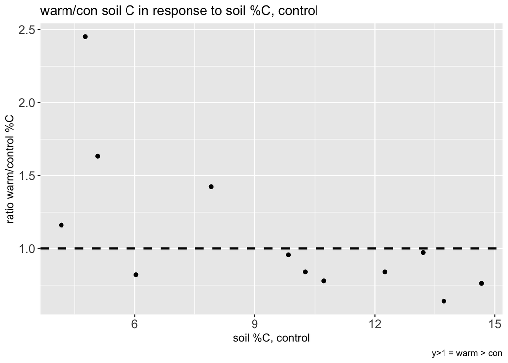

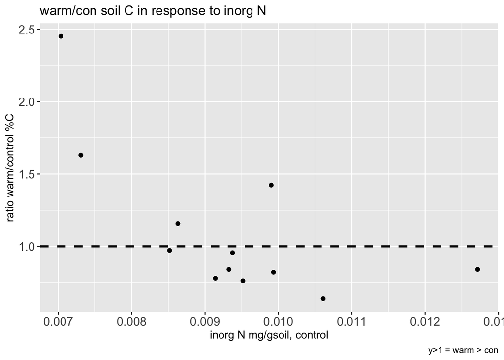

```
##
## Call:
## lm(formula = dCO2 ~ percC_control + inorgN_mgN_gsoil_control,
##     data = p_data)
##
## Residuals:
##     Min      1Q  Median      3Q     Max
## -1.0414 -0.5840 -0.0054  0.3017  3.3071
##
## Coefficients:
##                           Estimate Std. Error t value Pr(>|t|)
## (Intercept)                 3.5519     1.2547   2.831    0.010 *
## percC_control              -0.1319     0.0622  -2.121    0.046 *
## inorgN_mgN_gsoil_control -112.5182   155.9252  -0.722    0.478
## ---
## Signif. codes:  0 '***' 0.001 '**' 0.01 '*' 0.05 '.' 0.1 ' ' 1
##
## Residual standard error: 0.9158 on 21 degrees of freedom
## Multiple R-squared:  0.3101, Adjusted R-squared:  0.2444
## F-statistic:  4.72 on 2 and 21 DF,  p-value: 0.02029
```

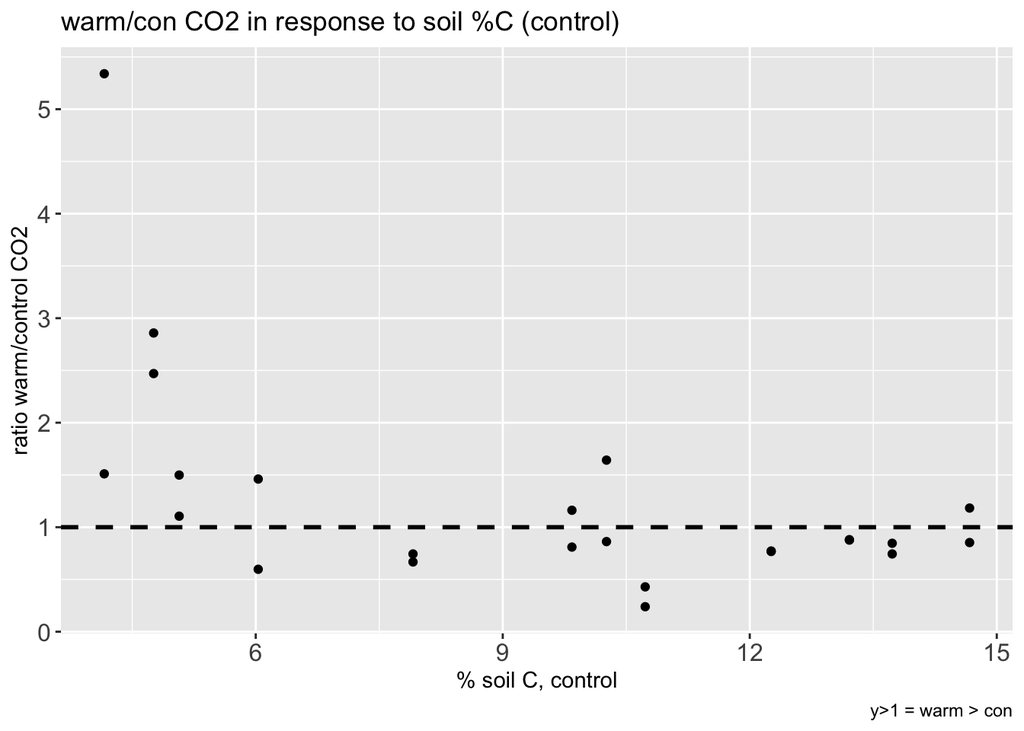